# Coral Reef Project

Michael Johnson

22 May, 2020

This data was retrieved from “Nature.com” and was constructed by lead author Nicholas A. J. Graham. It is centered around a group of coral reefs in the Seychelles Islands located off of the east coast of Africa and North of Madagascar. These reefs were severely impacted by the 1998 global coral bleaching event. When global pressures such as temperature, severe weather events, precipitation, ect, are increased due to climate change, it puts a great deal of stress on the corals and they end up “bleached”, basically dead and nutrient deprived and they turn white. This impacts the ecosystem around the corals as many fish and aquatic species depend on a healthy reef system. The goal of the research done in this article was to answer the following questions: “how effective are current conservation and management approaches in the context of a novel ecosystem”, and, “What are the lasting effects of climate change induced bleaching events on coral reefs”. The following graphics I have constructed answer those questions.

# Packages and Data

```r
library(tidyverse)
setwd("~/Documents/MTH250")
```

```r
reef1<-read.csv("CoralReef1.csv")
reef2<-read.csv("CoralReef2.csv")
reef3<-read.csv("CoralReef3.csv")
```

# Change in Benthic Habitat Post Bleaching

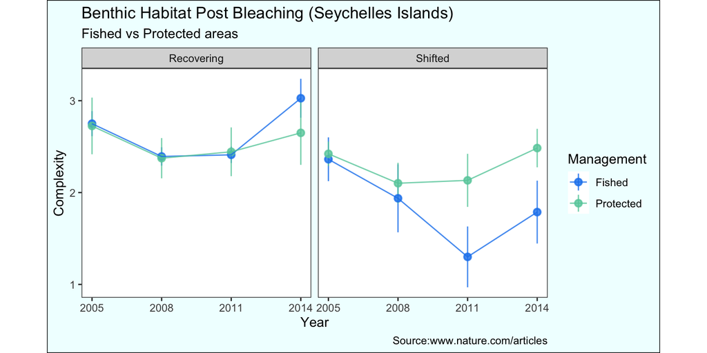

```r
colors<- c("dodgerblue2","aquamarine3")

ggplot(data = reef2,mapping=aes(x=Year,y=complexity))+
  stat_summary(alpha=.8,fun.data=mean_se,geom="pointrange",aes(color=Management)) +
  stat_summary(alpha=.8,fun =mean,geom="line",aes(color=Management)) +
  facet_wrap(vars(state))+
  theme_bw()+
  theme(panel.grid.major.x = element_blank(),panel.grid.minor.x = element_blank(),panel.grid.major.y = element_blank(),panel.grid.minor.y = element_blank())+
  scale_x_continuous(name = "Year",breaks = seq(2005,2014,3))+
  scale_y_continuous(name = "Complexity",breaks = seq(1,3,1))+
  scale_color_manual(values = colors)+
  labs(title = "Benthic Habitat Post Bleaching (Seychelles Islands)",subtitle = "Fished vs Protected areas",caption = "Source:www.nature.com/articles")+
  theme(aspect.ratio=1)+
  theme(plot.background=element_rect(fill="azure",color="black"))+
  theme(legend.background = element_rect(fill="azure",color="azure"))
```

Fig1. This plot is comparing the overall ecological complexity (reef “health”) of the Seychelles reefs through the years 2005 to 2014 after the bleaching event. These graphs are faceted by state of the coral reefs. The “state” refers to if the reef is “recovering” to pre bleaching health, or “shifting” to a different regime (ecosystem) because it could not bounce back. In these two different categories of state, there are two different Managed areas. In the deeper blue we see the Fished areas and the aquamarine the Protected areas where no fishing is allowed. I choose to facet the graphs by state as the state is a distinct category of the reef that can easily be visualized. I chose the blueish color and the greenish color to be close enough in pallet that they look related to each other but different enough to be able to clearly depict each point and line. I added a slight alpha in order to deal with parts of the lines and points overlapping. I chose the light sky blue background because it is in the same realm as my plot colors and ties the two graphs together very nicely in my mind. I chose to illustrate complexity as it was a very easy characteristic to visualize if you knew nothing about reefs or ecology. We obviously see here that recovering reefs are overall healthier than a shifted regime reef that is changing. Those shifted reefs are even worse off if they are fished, as seen in the graph. We also see a trend with both states of reefs as the years go on they start decreasing in complexity, however near 2011 we see the reefs start getting healthier again with a more positive direction of both managed areas. So overall recovering reefs have greater complexity over shifted regime reefs. However, what is interesting to me was how fished reefs started recovering faster than protected reefs in the recovering state, whereas it’s the opposite for shifted. I also included the standard error bars for the points so we can see where the data could be due to variability, more positive or more negative than the line we see now.

# Biomass vs Species Richness

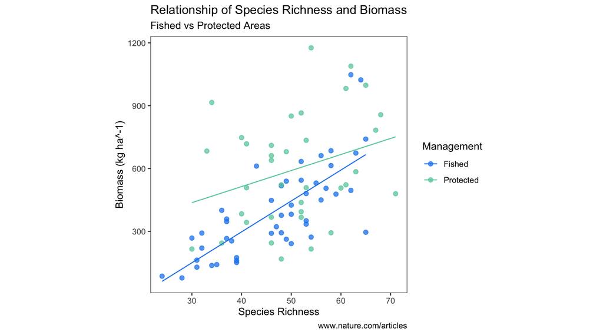

```r
colors<- c("dodgerblue2","aquamarine3")

ggplot(data = reef3,mapping=aes(x=species.richness,y=biomass,color=Management))+
  geom_point(size=2,alpha=.75)+
  scale_x_continuous(name="Species Richness")+
  scale_y_continuous(name="Biomass (kg ha^-1)")+
  theme_bw()+
  theme(panel.grid.major.x = element_blank(),panel.grid.minor.x = element_blank(),panel.grid.major.y = element_blank(),panel.grid.minor.y = element_blank())+
  scale_color_manual(values = colors)+
  scale_fill_manual(values = colors)+
  labs(title = "Relationship of Species Richness and Biomass",subtitle = "Fished vs Protected Areas", caption = "www.nature.com/articles")+
  geom_smooth(method = "lm",se=FALSE,size=.5)+
  theme(aspect.ratio = 1)
```

Fig2. This plot is examining the relationship between Biomass and Species Richness. Overall as richness increases generally so does biomass. However, I fit a linear model to each category of managed areas (fished and protected) to better understand the slope and direction of each category. I chose the colors to stand out from each other but still be easy on the eyes and easily be visualized. We can see however on average, fished areas seem to have less biomass than protected areas, most likely due to the safety a protected non fished area offers species. I chose a scatterplot to easily see the relationship and what happens to one variable as the other increases.